# Solutions to Exercises of Introduction to Statistical Learning, Chapter 5

Guillermo Martinez Dibene

25th of April, 2021

This chapter is all about validation, including cross-validation and bootstrap.

## Cross-Validation

The basic idea of cross validation is to shuffle the data set, pick a training set and a test set. Now choose a number $k$ in which the training set will be divided. Divide the training set into $k$ different groups $T_1, \ldots, T_k$ and for $i = 1, \ldots, k$ fit the model using all but the $T_i$ subset of the training set. Evaluate this fit using $T_i$ and call $\mathrm{MSE}_i$ the resulting mean squared error (or the misclassification error). The $k$-fold cross-validation testing error estimate is then
$$\mathrm{MSE}_{k-\mathrm{CV}} = \dfrac{1}{k} \sum_{i = 1}^k e_i,$$
this is the estimate for the test error. We can then use the testing set and see how close the $k$-fold cross-validation error actually was to the test error.

#### Caveat

The main use of cross-validation is to more effectively estimate the error of a model than simple validation. This is specially useful when we are varying parameters, use cross-validation for each selection of parameters, and then select the parameter set that minimised the found cross-validations. More mathematically, we define $f(\theta)$ to be the error estimate found using cross-validation when the parameters that the model employed were $\theta = (\theta_1, \ldots, \theta_k)$. Then, we choose the best parameter as $\theta^* = \mathop{\arg\min}_\limits\theta f(\theta)$.

## Bootstrap

In this method, we assume we have a sample $X_1, \ldots, X_n$ of independent random variables following the same distibution $F.$ We then approximate the variance of $F$, denote $\sigma_F^2,$ using the “plug-in” statistic of $F$, in this case, the “empircal distribution function” which we denote by $F_n$ (this distribution depends on the given sample). We know the shape of $F_n$ explicitly (it assigns mass $\frac{1}{n}$ to each point in our sample). So, we can take a very large sample from $F_n,$ say a sample of size $B$, call it $X_1^*, \ldots, X_B^*$ (by definition, this is a sample from $X_1, \ldots, X_n$ *with replacement*) and then estimate
$$\sigma_{F_n}^2 \approx v_n^{(\mathrm{boot})} := \dfrac{1}{B} \sum_{i = 1}^B \left( X_i^* - \mu_n^{(\mathrm{boot})} \right)^2$$
where $\mu_n^{(\mathrm{boot})} = \dfrac{1}{B} \sum\limits_{i = 1}^B X_i^*$. Finally, we are doing the following approximation
$$\sigma_F^2 \approx \sigma_{F_n}^2 \approx v_n^{(\mathrm{boot})}.$$
(The first of these two approximation **cannot be measure** but it is known it decreases as the sample size $n$ increases; the second approximation can be made arbitrarily close to zero by setting $B$ to be very large.)

#### Caveat

It is important to keep in mind that the first approximation $\sigma_F^2 \approx \sigma_{F_n}^2$ cannot be measured since we do not know what the “real” distribution function $F$ is. Yet, we know that $F_n \to F$ as $n \to \infty$ (by Glivenko-Cantelli theorem in the case of a single predictor, that is, when $p = 1$). (I could not find a reference on how fast the convergence is or the case of multiple predictors. In the exercises 5 and 6, $p = 2$.) On the other hand, logistic regression assumes the data to be independent $(X_1, Y_1), \ldots, (X_n, Y_n)$ with
$$\begin{align*}
Y_i|X_i = x_i &\sim \mathrm{Ber}(p(\theta, x_i)), \quad x_i = (x_{i,1}, \ldots, x_{i,p}),\\
\mathrm{logit}\ p(\theta, x_i) &= \theta_0 + \sum_{j = 1}^p \theta_j x_{i, j}, \quad \theta = (\theta_0, \ldots, \theta_p)
\end{align*}$$
and if these assumptions fail or are far from reality, the bootstrap method will yield more accurate results.

# Exercise 5

In this exercise we will analyse the `Default` data set. We will use `income` and `balance` to predict `default`.

```r
Default$id = 1:nrow(Default)
#We take 75% of the data for training
default_train <- Default %>%
    slice_sample(prop = .75)
default_test = dplyr::anti_join(Default, default_train, by = "id")
```

We do a first some visualisations of this data.

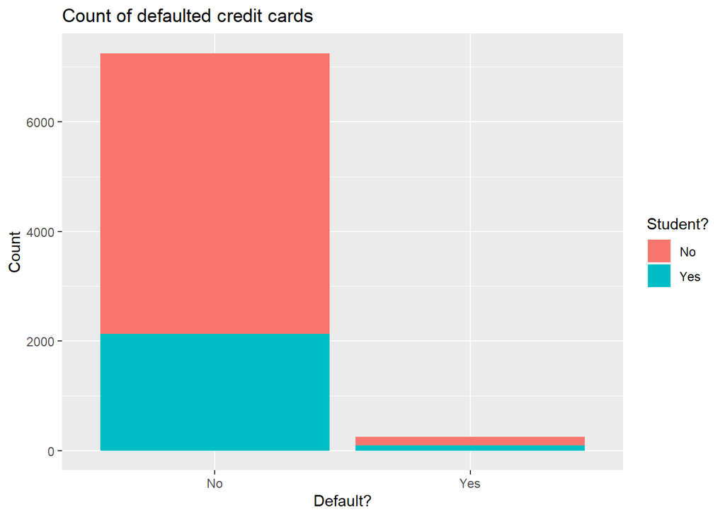

```r
default_train %>% ggplot(aes(default)) +
    geom_bar(aes(fill = student)) +
    labs(title = "Count of defaulted credit cards", x = "Default?", y = "Count", fill = "Student?")
```

We can see that overwhelmingly, people did not defaulted their credit cards. The percentage who defaulted is **3%**.

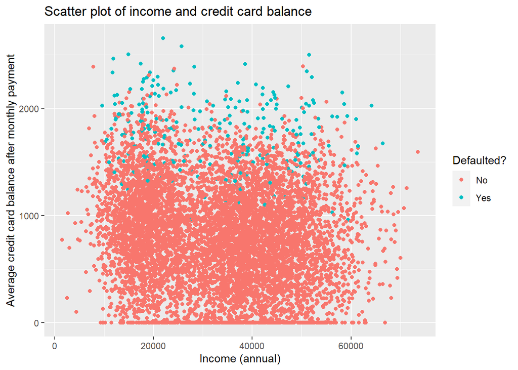

```r
default_train %>% ggplot(aes(income, balance, colour = default)) +
    geom_point() +
    labs(title = "Scatter plot of income and credit card balance", colour = "Defaulted?", x = "Income (annual)", y = "Average credit card balance after monthly payment")
```

We now will fit a logistic regression using `balance` and `income`. As we saw in the previous scatter plot, there is little correlation between the two variables. The following code chunk simply creates the logistic model, then adds the predicted classes and constructs the confusion matrix of the given model.

```r
default_logis <- glm(default ~ income + balance, data = default_train, family = binomial)
default_logis_pred <- default_test %>%
    add_predictions(default_logis, type = "response") %>%
    mutate(
        pred_Class = ifelse(pred > 0.5, "Yes", "No"),
        pred_Class = as_factor(pred_Class)
    )
cm_logis <- default_logis_pred %>%
    group_by(default, pred_Class) %>%
    count() %>%
    pivot_wider(
        names_from = default,
        values_from = n,
        names_prefix = "actual_",
        values_fill = 0
    )
```

The confusion matrix is

```r
cm_logis
```

```
## # A tibble: 2 x 3
## # Groups:   pred_Class [2]
##   pred_Class actual_No actual_Yes
##   <fct>          <int>      <int>
## 1 No              2413         63
## 2 Yes                2         22
```

We now will do a 10-fold cross-validation to find the classifier error rate

```r
cv_logis <- cv.glm(default_train, default_logis, K = 10)
cv_logis$delta[1]
```

```
## [1] 0.02129009
```

### Adding a the Student indicator variable

We now fit a second logitstic regression model in which we include the indicator variable as to whether or not the given person is a `student`.

```r
default_logis_student <- glm(formula = default ~ . - default, data = default_train, family = binomial)
default_logis_student_pred <- default_test %>%
    add_predictions(default_logis_student, type = "response") %>%
    mutate(
        pred_Class = ifelse(pred > 0.5, "Yes", "No"),
        pred_Class = as_factor(pred_Class)
    )
cm_logis_student <- default_logis_student_pred %>%
    group_by(default, pred_Class) %>%
    count() %>%
    pivot_wider(
        names_from = default,
        values_from = n,
        names_prefix = "actual_",
        values_fill = 0
    )
```

The confusion matrix is

```r
cm_logis_student
```

```
## # A tibble: 2 x 3
## # Groups:   pred_Class [2]
##   pred_Class actual_No actual_Yes
##   <fct>          <int>      <int>
## 1 No              2410         66
## 2 Yes                5         19
```

Which has a higher test error than the model with less predictors. Let us check what the 10-fold cross-validation predicts as what the error would be

```r
cv_logis_student <- cv.glm(default_train, default_logis_student, K = 10)
cv_logis_student$delta[1]
```

```
## [1] 0.02115203
```

It predicts an error of $2.12\%$ while the actual test error was $2.84\%$.

# Exercise 6

This is a continuation of **Exercise 5**, we are interested in estimating the standard errors of the coefficients in the logistic regression of `default` using `income` and `balance`.

The `summary()` function is now used to display the standard errors for the coefficients.

```r
summary(default_logis)
```

```
##
## Call:
## glm(formula = default ~ income + balance, family = binomial,
##     data = default_train)
##
## Deviance Residuals:
##     Min       1Q   Median       3Q      Max
## -2.4675  -0.1399  -0.0557  -0.0207   3.3511
##
## Coefficients:
##               Estimate Std. Error z value Pr(>|z|)
## (Intercept) -1.171e+01  5.071e-01 -23.098  < 2e-16 ***
## income       2.515e-05  5.803e-06   4.334 1.47e-05 ***
## balance      5.622e-03  2.612e-04  21.526  < 2e-16 ***
## ---
## Signif. codes:  0 '***' 0.001 '**' 0.01 '*' 0.05 '.' 0.1 ' ' 1
##
## (Dispersion parameter for binomial family taken to be 1)
##
##     Null deviance: 2178.7  on 7499  degrees of freedom
## Residual deviance: 1157.7  on 7497  degrees of freedom
## AIC: 1163.7
##
## Number of Fisher Scoring iterations: 8
```

Now, we will use the bootstrap method to estimate the standard error.

```r
coeff_statistic <- function(data, index) {
    return(coef(glm(default ~ income + balance, family = binomial, data = data, subset = index)))
}

boot(default_train, coeff_statistic, 1000)
```

```
##
## ORDINARY NONPARAMETRIC BOOTSTRAP
##
##
## Call:
## boot(data = default_train, statistic = coeff_statistic, R = 1000)
##
##
## Bootstrap Statistics :
##          original        bias     std. error
## t1* -1.171251e+01 -3.450278e-02 5.045890e-01
## t2*  2.514791e-05 -7.173050e-08 5.717811e-06
## t3*  5.622257e-03  1.914403e-05 2.578500e-04
```

It is clear that the point estimates are similar between the `summary()` output and the bootstrap method, as well as the standard errors, are very similar. This suggests that these are good reliable results.

# Exercise 9

In this exercise we will study the `Boston` housing data set and focus on its variable `medv` which is the median value of owner-occupied homes in thousands of dollars. First, we plot the histogram (this data set contains 506 observations), the blue line represents the median value, while the green one, the mean.

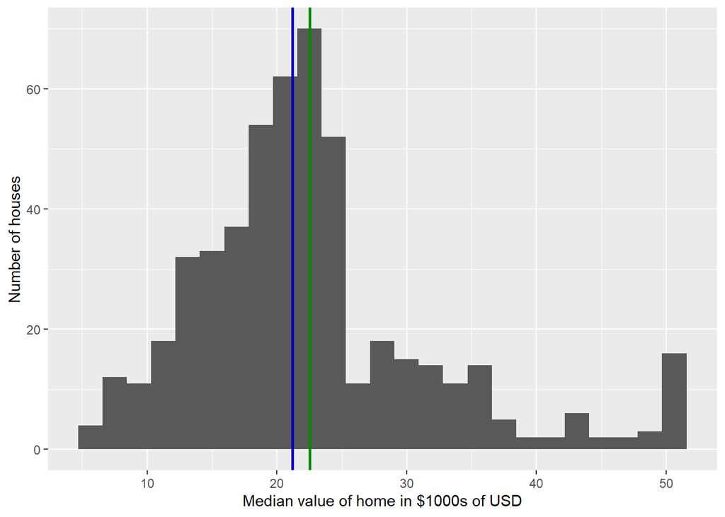

```r
mean_boston <- mean(Boston$medv)
med_boston <- median(Boston$medv)
Boston %>% ggplot(aes(medv)) +
    geom_histogram(bins = 25) +
    geom_ref_line(v = med_boston, size = 1, colour = "mediumblue") +
    geom_ref_line(v = mean_boston, size = 1, colour = "green4") +
    labs(x = "Median value of home in $1000s of USD", y = "Number of houses")
```

We are interested in finding a $95\%$ confidence interval for the sample median and sample mean, hereinafter denoted $\widehat{\mathrm{med}}$ and $\hat \mu$. The random variable $\hat \mu$ has variance $\mathbf{V}\mathrm{ar}(\hat \mu) = \dfrac{\sigma^2}{n}$, where $\sigma^2$ is the population variance of median house value; the variance of $\widehat{\mathrm{med}}$ has no closed form. First, for the mean,

```r
sd_mean_boston <- sd(Boston$medv) / sqrt(nrow(Boston))
sd_mean_boston
```

```
## [1] 0.4088611
```

For the median we need to use the bootstrap method.

```r
median_sd_statistic <- function(data, index) {
    temp = data$medv[index]
    return(median(temp))
}
boot(Boston, median_sd_statistic, 1000)
```

```
##
## ORDINARY NONPARAMETRIC BOOTSTRAP
##
##
## Call:
## boot(data = Boston, statistic = median_sd_statistic, R = 1000)
##
##
## Bootstrap Statistics :
##     original  bias    std. error
## t1*     21.2  -0.048   0.4009386
```

Since there are hundreds of observations, is quite safe to use normal approximation to compute the $95\%$ confidence intervals, which take the form $\hat x \pm 2 \cdot \widehat{sd}$, where $\hat{x}$ is the estimated value of the statistic of interest and $\widehat{sd}$ is the estimated standard deviation.

[output not shown]

We also calculate the $95\%$ confidence interval for the first quartile $\hat{q}_{0.25}.$

```r
first_quartile_statistic <- function(data, index) {
    temp = data$medv[index]
    return(quantile(temp, probs = 0.25))
}
boot(Boston, first_quartile_statistic, 1000)
```

```
##
## ORDINARY NONPARAMETRIC BOOTSTRAP
##
##
## Call:
## boot(data = Boston, statistic = first_quartile_statistic, R = 1000)
##
##
## Bootstrap Statistics :
##     original    bias    std. error
## t1*   17.025 -0.092475   0.5534203
```

With this data, we can easily calculate the desired confidence interval

| Statistic | Estimated $95\%$ confidence interval |
| --- | --- |
| $\hat{q}_{0.25}$ | $[15.92,\ 18.13]$ |

Finally, we mention again that for both quartiles $q_{0.25}$ and $q_{.50} = \mathrm{med}$, there is no closed form for the standard error, so the bootstrap method really is quite handy.